# Homework 1 Solution

326.414 Nonparametric Statistics and Lab.

Author

Jun Seok Lee

Published

April 9, 2026

```r
# install.packages(c("ggplot2", "knitr"))

library(ggplot2)
library(knitr)
```

```r
alpha <- 0.05
n_x <- 5
n_y <- 5
N <- n_x + n_y

method_names <- c(
  "등분산 t-test",
  "이분산 t-test",
  "Wilcoxon rank sum (exact)",
  "Wilcoxon rank sum (정규근사)",
  "Permutation test (등분산 t)",
  "Permutation test (이분산 t)"
)

# m = n = 5 이므로 가능한 모든 그룹 재배치 수는 choose(10, 5) = 252개이다.
# permutation test와 exact Wilcoxon 계산에 이 조합들을 미리 만들어 둔다.
all_y_idx <- combn(N, n_y)
all_x_idx <- apply(all_y_idx, 2, function(idx) setdiff(1:N, idx))
all_W <- colSums(all_y_idx)

# 행렬의 각 열 분산을 빠르게 계산하는 함수
col_var <- function(mat) {
  centered <- sweep(mat, 2, colMeans(mat), "-")
  colSums(centered^2) / (nrow(mat) - 1)
}
```

```r
# 표본 생성
make_data <- function(delta, n_x = 5, n_y = 5) {
  list(
    x = rnorm(n_x, mean = 0, sd = 1),
    y = rnorm(n_y, mean = delta, sd = 1)
  )
}

# 여섯 가지 검정 결과를 한 번에 정리
get_tests <- function(x, y) {
  stopifnot(length(x) == 5, length(y) == 5)

  n_x <- length(x)
  n_y <- length(y)
  N <- n_x + n_y

  mean_x <- mean(x)
  mean_y <- mean(y)
  var_x <- var(x)
  var_y <- var(y)
  mean_diff <- mean_y - mean_x

  # 등분산 two-sample t-test
  sp2 <- ((n_x - 1) * var_x + (n_y - 1) * var_y) / (N - 2)
  t_equal <- mean_diff / sqrt(sp2 * (1 / n_x + 1 / n_y))
  p_equal <- 1 - pt(t_equal, df = N - 2)

  # 이분산 t-test
  se2 <- var_x / n_x + var_y / n_y
  t_welch <- mean_diff / sqrt(se2)
  df_welch <- se2^2 / ((var_x / n_x)^2 / (n_x - 1) + (var_y / n_y)^2 / (n_y - 1))
  p_welch <- 1 - pt(t_welch, df = df_welch)

  # Wilcoxon rank sum exact
  ranks <- rank(c(x, y), ties.method = "average")
  W <- sum(ranks[(n_x + 1):N])
  p_wilcox_exact <- mean(all_W >= W)

  # Wilcoxon rank sum normal approximation
  mu_W <- n_y * (N + 1) / 2
  sd_W <- sqrt(n_x * n_y * (N + 1) / 12)
  z_wilcox <- (W - 0.5 - mu_W) / sd_W  # upper tail continuity correction
  p_wilcox_norm <- 1 - pnorm(z_wilcox)

  # permutation test
  z <- c(x, y)
  y_mat <- matrix(z[all_y_idx], nrow = n_y)
  x_mat <- matrix(z[all_x_idx], nrow = n_x)

  perm_mean_y <- colMeans(y_mat)
  perm_mean_x <- colMeans(x_mat)
  perm_var_y <- col_var(y_mat)
  perm_var_x <- col_var(x_mat)

  perm_t_equal <- (perm_mean_y - perm_mean_x) /
    sqrt((((n_x - 1) * perm_var_x + (n_y - 1) * perm_var_y) / (N - 2)) * (1 / n_x + 1 / n_y))

  perm_t_welch <- (perm_mean_y - perm_mean_x) /
    sqrt(perm_var_x / n_x + perm_var_y / n_y)

  p_perm_equal <- mean(perm_t_equal >= t_equal)
  p_perm_welch <- mean(perm_t_welch >= t_welch)

  data.frame(
    method = method_names,
    stat_label = c("t", "t", "W", "Z", "T_perm", "T_perm"),
    statistic = c(t_equal, t_welch, W, z_wilcox, t_equal, t_welch),
    df = c(N - 2, df_welch, NA, NA, NA, NA),
    p_value = c(
      p_equal,
      p_welch,
      p_wilcox_exact,
      p_wilcox_norm,
      p_perm_equal,
      p_perm_welch
    )
  )
}


run_one <- function(delta) {
  dat <- make_data(delta)
  tests <- get_tests(dat$x, dat$y)
  tests$reject <- ifelse(tests$p_value < alpha, "기각", "기각하지 않음")

  list(
    sample = data.frame(
      번호 = 1:5,
      X = dat$x,
      Y = dat$y
    ),
    summary = data.frame(
      group = c("X", "Y"),
      mean = c(mean(dat$x), mean(dat$y)),
      sd = c(sd(dat$x), sd(dat$y))
    ),
    tests = tests
  )
}

# 여러 번 반복하여 경험적 기각확률(= delta=0이면 제1종 오류, delta>0이면 power) 계산
run_many <- function(delta, n_rep = 1000) {
  p_mat <- replicate(n_rep, {
    dat <- make_data(delta)
    get_tests(dat$x, dat$y)$p_value
  })

  data.frame(
    method = method_names,
    reject_rate = rowMeans(p_mat < alpha)
  )
}

# power curve용 표 생성
make_power_curve <- function(delta_grid, n_rep = 1000) {
  out <- lapply(delta_grid, function(delta) {
    tmp <- run_many(delta, n_rep = n_rep)
    data.frame(
      delta = delta,
      method = tmp$method,
      power = tmp$reject_rate
    )
  })

  do.call(rbind, out)
}
```

## 문제 관찰

표본크기가 같을 때(여기서는 $m=n=5$)는 등분산 t 통계량과 이분산 t 통계량의 **통계량 값 자체는 같아진다**.

$$\sqrt{S_p^2\left(\frac{1}{n}+\frac{1}{n}\right)}
=
\sqrt{\frac{S_X^2 + S_Y^2}{n}}
=
\sqrt{\frac{S_X^2}{n} + \frac{S_Y^2}{n}}$$

따라서 이 과제에서는

- (1)번과 (2)번의 **t 통계량은 동일**하고,
- (5)번과 (6)번의 **permutation test 통계량도 동일**하다.

다만 1번과 2번은 자유도 계산 방식이 달라서 **p-value는 조금 다를 수 있다.**

## 문제 1: $\Delta = 0$에서 한 번 표본을 생성하여 6가지 검정 수행

```r
set.seed(2026)
one_case <- run_one(delta = 0)

sample_show <- one_case$sample
sample_show$X <- round(sample_show$X, 4)
sample_show$Y <- round(sample_show$Y, 4)
kable(sample_show, caption = "한 번 생성한 표본")
```

한 번 생성한 표본

| 번호 | X | Y |
| --- | --- | --- |
| 1 | 0.5206 | -2.5161 |
| 2 | -1.0797 | -0.7351 |
| 3 | 0.1392 | -1.0201 |
| 4 | -0.0847 | 0.1136 |
| 5 | -0.6666 | -0.4738 |

```r
summary_show <- one_case$summary
summary_show$mean <- round(summary_show$mean, 4)
summary_show$sd <- round(summary_show$sd, 4)
kable(summary_show, caption = "표본 요약")
```

표본 요약

| group | mean | sd |
| --- | --- | --- |
| X | -0.2343 | 0.6390 |
| Y | -0.9263 | 0.9822 |

```r
test_show <- one_case$tests
test_show$statistic <- round(test_show$statistic, 4)
test_show$df <- ifelse(is.na(test_show$df), "", round(test_show$df, 4))
test_show$p_value <- round(test_show$p_value, 4)
kable(test_show, caption = "여섯 가지 검정 결과")
```

여섯 가지 검정 결과

| method | stat_label | statistic | df | p_value | reject |
| --- | --- | --- | --- | --- | --- |
| 등분산 t-test | t | -1.3207 | 8 | 0.8884 | 기각하지 않음 |
| 이분산 t-test | t | -1.3207 | 6.8717 | 0.8856 | 기각하지 않음 |
| Wilcoxon rank sum (exact) | W | 22.0000 |  | 0.8889 | 기각하지 않음 |
| Wilcoxon rank sum (정규근사) | Z | -1.2534 |  | 0.8950 | 기각하지 않음 |
| Permutation test (등분산 t) | T_perm | -1.3207 |  | 0.8889 | 기각하지 않음 |
| Permutation test (이분산 t) | T_perm | -1.3207 |  | 0.8889 | 기각하지 않음 |

위 표에서 보듯이 여섯 방법의 p-value가 모두 0.05보다 크게 나왔다. 따라서 **어느 방법도 귀무가설을 기각하지 않는다.** 즉, $\Delta = 0$인 상황에서는 이번에 관측된 차이를 우연한 표본변동으로 볼 수 있다.

> 참고: seed를 다르게 주면 $\Delta = 0$이어도 우연히 기각되는 경우가 있다. 바로 그 비율을 문항 2에서 **제1종 오류**로 확인한다.

## 문제 2: 제1종 오류(Type I error)

문제 조건에 따라 $\Delta = 0$에서 같은 과정을 1,000번 반복한다.

```r
type1 <- run_many(delta = 0, n_rep = 1000)

type1_show <- type1
type1_show$reject_rate <- round(type1_show$reject_rate, 4)
kable(type1_show, caption = "문제 2: 제1종 오류 추정치 (1,000회 반복)")
```

문제 2: 제1종 오류 추정치 (1,000회 반복)

| method | reject_rate |
| --- | --- |
| 등분산 t-test | 0.065 |
| 이분산 t-test | 0.061 |
| Wilcoxon rank sum (exact) | 0.062 |
| Wilcoxon rank sum (정규근사) | 0.062 |
| Permutation test (등분산 t) | 0.061 |
| Permutation test (이분산 t) | 0.061 |

경험적 제1종 오류는 대체로 0.061에서 0.065 사이로, 명목 유의수준 0.05보다 다소 크게 나타났다.  
따라서 여섯 방법은 전반적으로 비슷한 수준의 제1종 오류를 보였지만, 유의수준 0.05를 정확히 맞춘다고 보기는 어렵다.

## 문제 3, 4: power 계산

이번에는 $\Delta = 1$, $\Delta = 2$에서 각각 1,000번 반복하여 power를 계산한다.

```r
power_1 <- run_many(delta = 1, n_rep = 1000)
power_2 <- run_many(delta = 2, n_rep = 1000)

power_compare <- data.frame(
  method = power_1$method,
  `Delta = 1` = round(power_1$reject_rate, 4),
  `Delta = 2` = round(power_2$reject_rate, 4),
  check.names = FALSE
)

kable(power_compare, caption = "문제 3, 4: power 비교 (각 1,000회 반복)")
```

문제 3, 4: power 비교 (각 1,000회 반복)

| method | Delta = 1 | Delta = 2 |
| --- | --- | --- |
| 등분산 t-test | 0.410 | 0.895 |
| 이분산 t-test | 0.396 | 0.885 |
| Wilcoxon rank sum (exact) | 0.386 | 0.863 |
| Wilcoxon rank sum (정규근사) | 0.386 | 0.863 |
| Permutation test (등분산 t) | 0.395 | 0.886 |
| Permutation test (이분산 t) | 0.394 | 0.884 |

해석은 다음과 같다.

- $\Delta = 1$일 때는 power가 $0.386$ ~ $0.410$이며, 표본크기가 5대5로 작기 때문에 완전히 높지는 않다.
- $\Delta = 2$일 때는 power가 크게 증가한다. 즉, **평균 차이가 커질수록 검정력이 높아진다.**
- **정규분포 + 등분산**이라는 모형이 정확히 맞는 상황에서는 t-test 계열과 t-statistic 기반 permutation test가 대체로 조금 더 power가 높은 경향을 보인다.
- Wilcoxon 계열도 power가 잘 증가하지만, 완전히 정규모형이 맞는 상황에서는 t-test보다 약간 작을 수 있다.

> 참고: 표본크기가 같기 때문에 `Permutation test (등분산 t)`와 `Permutation test (이분산 t)`의 결과가 사실상 같게 나온다.

## Power curve 비교

문제 3, 4의 결과를 점 두 개로만 보는 대신, $\Delta$가 커질 때 power가 어떻게 변하는지 곡선으로 확인해 보자.

여기서는 $\Delta$ = 0, 0.25, 0.50, $\dots$, 2.50에서 각 점마다 1,000회 반복으로 power를 계산한다.

```r
delta_grid <- seq(0, 2.5, by = 0.25)


power_curve <- make_power_curve(delta_grid, n_rep = 1000)
power_curve$method <- factor(power_curve$method, levels = method_names)

curve_show <- power_curve
curve_show$power <- round(curve_show$power, 4)
kable(curve_show, caption = "Power curve 계산 결과")
```

Power curve 계산 결과

| delta | method | power |
| --- | --- | --- |
| 0.00 | 등분산 t-test | 0.054 |
| 0.00 | 이분산 t-test | 0.051 |
| 0.00 | Wilcoxon rank sum (exact) | 0.051 |
| 0.00 | Wilcoxon rank sum (정규근사) | 0.051 |
| 0.00 | Permutation test (등분산 t) | 0.050 |
| 0.00 | Permutation test (이분산 t) | 0.050 |
| 0.25 | 등분산 t-test | 0.100 |
| 0.25 | 이분산 t-test | 0.093 |
| 0.25 | Wilcoxon rank sum (exact) | 0.095 |
| 0.25 | Wilcoxon rank sum (정규근사) | 0.095 |
| 0.25 | Permutation test (등분산 t) | 0.097 |
| 0.25 | Permutation test (이분산 t) | 0.097 |
| 0.50 | 등분산 t-test | 0.167 |
| 0.50 | 이분산 t-test | 0.153 |
| 0.50 | Wilcoxon rank sum (exact) | 0.162 |
| 0.50 | Wilcoxon rank sum (정규근사) | 0.162 |
| 0.50 | Permutation test (등분산 t) | 0.159 |
| 0.50 | Permutation test (이분산 t) | 0.160 |
| 0.75 | 등분산 t-test | 0.287 |
| 0.75 | 이분산 t-test | 0.278 |
| 0.75 | Wilcoxon rank sum (exact) | 0.270 |
| 0.75 | Wilcoxon rank sum (정규근사) | 0.270 |
| 0.75 | Permutation test (등분산 t) | 0.285 |
| 0.75 | Permutation test (이분산 t) | 0.283 |
| 1.00 | 등분산 t-test | 0.402 |
| 1.00 | 이분산 t-test | 0.386 |
| 1.00 | Wilcoxon rank sum (exact) | 0.386 |
| 1.00 | Wilcoxon rank sum (정규근사) | 0.386 |
| 1.00 | Permutation test (등분산 t) | 0.395 |
| 1.00 | Permutation test (이분산 t) | 0.394 |
| 1.25 | 등분산 t-test | 0.561 |
| 1.25 | 이분산 t-test | 0.543 |
| 1.25 | Wilcoxon rank sum (exact) | 0.526 |
| 1.25 | Wilcoxon rank sum (정규근사) | 0.526 |
| 1.25 | Permutation test (등분산 t) | 0.543 |
| 1.25 | Permutation test (이분산 t) | 0.545 |
| 1.50 | 등분산 t-test | 0.709 |
| 1.50 | 이분산 t-test | 0.692 |
| 1.50 | Wilcoxon rank sum (exact) | 0.668 |
| 1.50 | Wilcoxon rank sum (정규근사) | 0.668 |
| 1.50 | Permutation test (등분산 t) | 0.695 |
| 1.50 | Permutation test (이분산 t) | 0.693 |
| 1.75 | 등분산 t-test | 0.824 |
| 1.75 | 이분산 t-test | 0.810 |
| 1.75 | Wilcoxon rank sum (exact) | 0.795 |
| 1.75 | Wilcoxon rank sum (정규근사) | 0.795 |
| 1.75 | Permutation test (등분산 t) | 0.820 |
| 1.75 | Permutation test (이분산 t) | 0.819 |
| 2.00 | 등분산 t-test | 0.863 |
| 2.00 | 이분산 t-test | 0.852 |
| 2.00 | Wilcoxon rank sum (exact) | 0.849 |
| 2.00 | Wilcoxon rank sum (정규근사) | 0.849 |
| 2.00 | Permutation test (등분산 t) | 0.849 |
| 2.00 | Permutation test (이분산 t) | 0.850 |
| 2.25 | 등분산 t-test | 0.947 |
| 2.25 | 이분산 t-test | 0.942 |
| 2.25 | Wilcoxon rank sum (exact) | 0.926 |
| 2.25 | Wilcoxon rank sum (정규근사) | 0.926 |
| 2.25 | Permutation test (등분산 t) | 0.941 |
| 2.25 | Permutation test (이분산 t) | 0.941 |
| 2.50 | 등분산 t-test | 0.974 |
| 2.50 | 이분산 t-test | 0.972 |
| 2.50 | Wilcoxon rank sum (exact) | 0.959 |
| 2.50 | Wilcoxon rank sum (정규근사) | 0.959 |
| 2.50 | Permutation test (등분산 t) | 0.973 |
| 2.50 | Permutation test (이분산 t) | 0.974 |

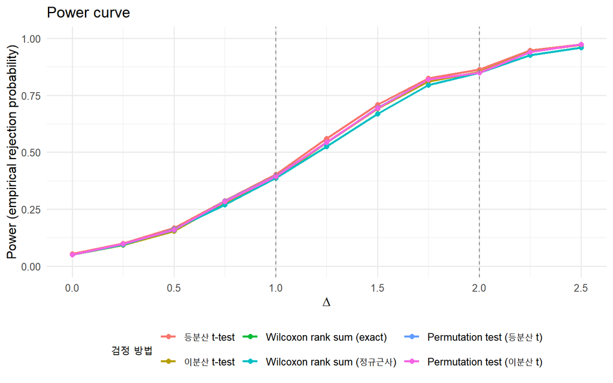

여섯 가지 검정의 power curve

```r
ggplot(power_curve, aes(x = delta, y = power, color = method)) +
  geom_line(size = 1) +
  geom_point(size = 2) +
  geom_vline(xintercept = c(1, 2), linetype = 2, color = "gray50") +
  scale_x_continuous(breaks = seq(0, 2.5, by = 0.5)) +
  coord_cartesian(ylim = c(0, 1)) +
  labs(
    title = "Power curve",
    x = expression(Delta),
    y = "Power (empirical rejection probability)",
    color = "검정 방법"
  ) +
  theme_minimal(base_size = 12) +
  theme(legend.position = "bottom")
```

## Power curve 해석

power curve에서 읽을 수 있는 핵심은 다음과 같다.

1. **$\Delta$가 커질수록 모든 방법의 power가 증가한다.**
   - 평균 차이가 더 커지면 귀무가설을 기각하기 쉬워지는 것이 자연스럽게 나타난다.
2. **현재 상황에서는 t-test 계열이 조금 더 위에 있는 경우가 많다.**
   - 이는 데이터를 정규분포에서 생성해서 t-test의 정규성 가정을 충족시켰기 때문이다.
3. **Wilcoxon exact와 Wilcoxon 정규근사 곡선은 거의 겹친다.**
   - 이 문제에서는 두 방법의 차이가 아주 크지 않다는 것을 보여준다.
4. **Permutation test는 대응되는 t-statistic 기반 검정과 매우 비슷하게 움직인다.**
   - 특히 표본크기가 같아서 통계량 형태가 거의 동일하게 작동한다.